# Demystifying R Survey Report

# About our Respondents

We did a survey on September 12, 2019. We received responses from 7 people.

## Age

Respondents listed their age. The youngest respondent was 22 years old and the oldest respondent was 35. The mean age was 28.2.

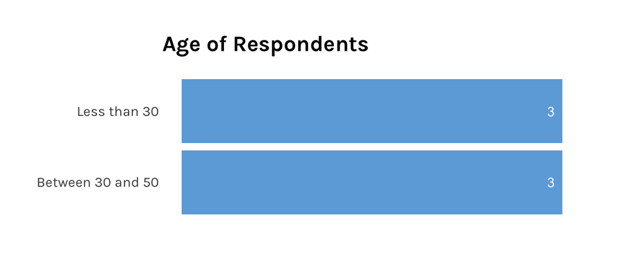

## Education

The education levels of respondents are below.

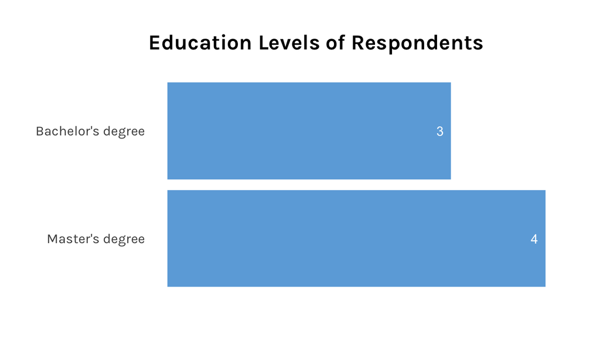

## Locations

Respondents listed the location of their primary residence. The map below shows their locations.

[interactive chart not shown]

## Gender

Respondents were asked to list their gender, in whatever form they choose to identify it.

The original responses are below.

| Gender (Original Response) |
| --- |
| Male |
| male |
| Female |
| woman |
| cis female |
| Non-binary |

We then used the [gendercodeR package](https://github.com/ropenscilabs/gendercoder) to recode responses. The table below shows the original responses and the recoded responses.

| Original Responses | Recoded Gender |
| --- | --- |
| Male | Male |
| male | Male |
| Female | Female |
| woman | Female |
| cis female | Cis Female |
| Non-binary | Non-Binary |

We can then summarize the recoded responses, which we do in the following table.

| Recoded Gender | Number of Responses |
| --- | --- |
| Cis Female | 1 |
| Female | 2 |
| Male | 2 |
| Non-Binary | 1 |

# Familiarity with R

On a 5-point scale, respondents listed their level of familiarity with R as 1.7. The figure below shows familiarity broken down by education level.

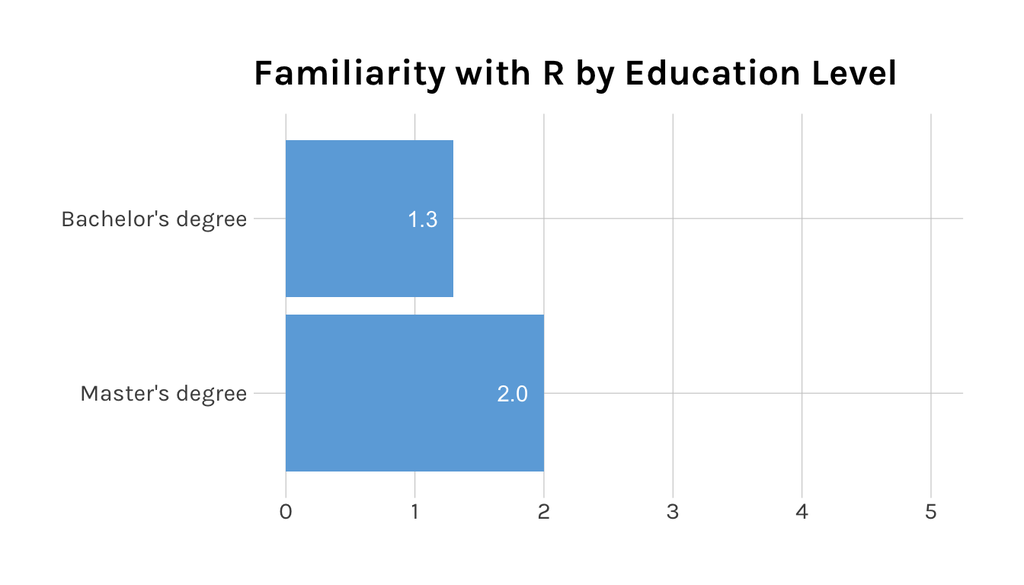

# Interest in Learning R

We can do a similar breakdown, but adding age. With one line of code, we can make small multiples.

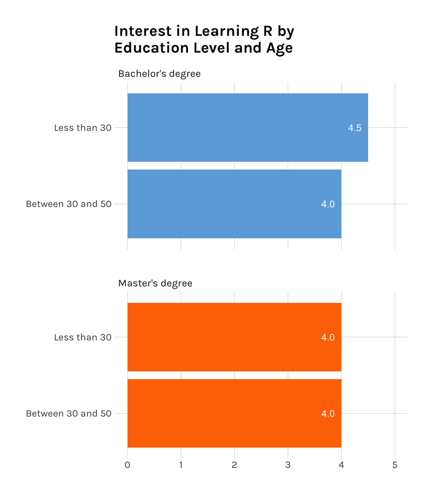